# Chicago Taxi Trips in Year 2022

#### Copyright © 2026 Danny Ng

```python
import matplotlib.pyplot as plt
import numpy as np
import pandas as pd
import seaborn as sns

%config InlineBackend.figure_format='retina'
```

# Step 1: Read the data

```python
df = pd.read_csv('chicago_taxi_trip_sample.csv.zip')
```

```python
df.shape
```

```
(100000, 17)
```

```python
df.info()
```

```
<class 'pandas.DataFrame'>
RangeIndex: 100000 entries, 0 to 99999
Data columns (total 17 columns):
 #   Column        Non-Null Count   Dtype
---  ------        --------------   -----
 0   trip_id       100000 non-null  str
 1   taxi_id       100000 non-null  str
 2   month         100000 non-null  int64
 3   day_of_week   100000 non-null  int64
 4   hour          100000 non-null  int64
 5   pickup_area   100000 non-null  str
 6   dropoff_area  100000 non-null  str
 7   trip_miles    100000 non-null  float64
 8   trip_seconds  100000 non-null  int64
 9   fare          100000 non-null  float64
 10  tips          100000 non-null  float64
 11  tips_percent  100000 non-null  float64
 12  tolls         100000 non-null  float64
 13  extras        100000 non-null  float64
 14  trip_total    100000 non-null  float64
 15  payment_type  100000 non-null  str
 16  company       100000 non-null  str
dtypes: float64(7), int64(4), str(6)
memory usage: 18.1 MB
```

```python
df.head(2)
```

|  | trip_id | taxi_id | month | day_of_week | hour | pickup_area | dropoff_area | trip_miles | trip_seconds | fare | tips | tips_percent | tolls | extras | trip_total | payment_type | company |
| --- | --- | --- | --- | --- | --- | --- | --- | --- | --- | --- | --- | --- | --- | --- | --- | --- | --- |
| 0 | 259f9c40ef9 | f9bc93 | 1 | 5 | 0 | Other | Other | 0.35 | 151 | 4.25 | 0.0 | 0.0 | 0.0 | 1.0 | 5.25 | Cash | City Service |
| 1 | 0f61207c6d8 | 271cde | 1 | 5 | 0 | Downtown | Other | 0.53 | 918 | 8.50 | 0.0 | 0.0 | 0.0 | 0.0 | 8.50 | Cash | Sun Taxi |

```python
df.tail(2)
```

|  | trip_id | taxi_id | month | day_of_week | hour | pickup_area | dropoff_area | trip_miles | trip_seconds | fare | tips | tips_percent | tolls | extras | trip_total | payment_type | company |
| --- | --- | --- | --- | --- | --- | --- | --- | --- | --- | --- | --- | --- | --- | --- | --- | --- | --- |
| 99998 | ed987453c4c | a48535 | 12 | 5 | 23 | Downtown | Other | 4.09 | 804 | 14.0 | 0.0 | 0.0 | 0.0 | 1.0 | 15.0 | Cash | City Service |
| 99999 | 6f2cde448af | 361804 | 12 | 5 | 23 | Other | Other | 13.10 | 1080 | 33.0 | 0.0 | 0.0 | 0.0 | 0.0 | 33.0 | Other | Taxi Affiliation Services |

```python
df.describe().transpose().astype({'count': int}) # Only numerical columns
```

|  | count | mean | std | min | 25% | 50% | 75% | max |
| --- | --- | --- | --- | --- | --- | --- | --- | --- |
| month | 100000 | 6.936080 | 3.229650 | 1.00 | 4.0 | 7.000 | 10.00 | 12.000 |
| day_of_week | 100000 | 2.882130 | 1.899382 | 0.00 | 1.0 | 3.000 | 4.00 | 6.000 |
| hour | 100000 | 13.862130 | 5.221752 | 0.00 | 10.0 | 14.000 | 18.00 | 23.000 |
| trip_miles | 100000 | 6.121182 | 6.374934 | 0.01 | 1.2 | 2.900 | 10.60 | 83.000 |
| trip_seconds | 100000 | 1156.478920 | 905.061445 | 1.00 | 489.0 | 869.000 | 1585.00 | 7197.000 |
| fare | 100000 | 20.141239 | 14.962318 | 3.25 | 8.0 | 13.250 | 30.75 | 187.250 |
| tips | 100000 | 2.511505 | 3.578416 | 0.00 | 0.0 | 1.000 | 3.39 | 50.000 |
| tips_percent | 100000 | 0.133331 | 0.178893 | 0.00 | 0.0 | 0.062 | 0.23 | 11.111 |
| tolls | 100000 | 0.001443 | 0.075218 | 0.00 | 0.0 | 0.000 | 0.00 | 7.000 |
| extras | 100000 | 1.067526 | 1.897453 | 0.00 | 0.0 | 0.000 | 1.00 | 20.000 |
| trip_total | 100000 | 23.883756 | 18.307585 | 3.25 | 10.0 | 15.900 | 32.75 | 187.250 |

```python
df.describe(include=str).transpose() # Only non-numerical columns
```

|  | count | unique | top | freq |
| --- | --- | --- | --- | --- |
| trip_id | 100000 | 100000 | 259f9c40ef9 | 1 |
| taxi_id | 100000 | 2736 | 8da9e1 | 175 |
| pickup_area | 100000 | 4 | Downtown | 48862 |
| dropoff_area | 100000 | 4 | Other | 47745 |
| payment_type | 100000 | 3 | Credit Card | 38222 |
| company | 100000 | 28 | Flash Cab | 21272 |

# Step 2: Define business problem

#### Business Problem

> The Chicago Department of Transportation is interested in traffic patterns. In particular, they want to understand how Chicago taxi trip duration is related to other factors of the trip.

#### Task

> Build a linear regression model using historical Chicago taxi trip data from year 2022 with `trip_seconds` as the response variable and other useful information as explanatory variables.

#### Some Considerations

- **Easy or difficulty task?**
  - Intuitively, `trip_miles` or `fare` are likely the most predictive / useful explanatory variable with a strong linear relationship.
  - Does the linear regression model predicts more accurately for some part of the data?
- **Overfitting**
  - If `trip_id` is used as an explanatory variable, then it would surely exhaust the number of degrees of freedom of the model and yield 0 residual error i.e. overfit.
- **Feature engineering**
  - Perform some feature engineering e.g. additional explanatory variables (such as month of year, day of week, hour of day, specific special dates) derived from `trip_start_time`, categorical variables for selected pick-up or drop-off locations, `tips` percentage, indicator variable for presence of `tolls`.
  - Perform variable transformation on some quantitative variables might strengthen the linear relationship (from non-linear).
- **Multicollinearity**
  - Some explanatory variables might be highly correlated e.g. `trip_miles`, `fare` (and etc summation), `trip_total`, distance derived from pick-up vs drop-off locations, or even `payment_type`. This can affect the explainability of the model.
- **Others**
  - Is (popular) `taxi_id` useful or not? Any anomaly or interesting behavior for specific taxi cab?
  - Any negative predicted `trip_seconds` value?

# Step 3: Do feature engineering

- See `chicago_taxi_trip_sampling.ipynb`

# Step 4: Exploratory data analysis and visualization

```python
# Correlation matrix of numerical variables
numerical_cols = ['trip_seconds', 'trip_miles', 'fare', 'tips', 'tolls', 'extras', 'trip_total', 'tips_percent']
C = df[numerical_cols].corr()

C
```

|  | trip_seconds | trip_miles | fare | tips | tolls | extras | trip_total | tips_percent |
| --- | --- | --- | --- | --- | --- | --- | --- | --- |
| trip_seconds | 1.000000 | 0.731877 | 0.824167 | 0.423448 | 0.019853 | 0.426638 | 0.801559 | -0.076842 |
| trip_miles | 0.731877 | 1.000000 | 0.903163 | 0.508655 | 0.023787 | 0.508376 | 0.892731 | -0.042703 |
| fare | 0.824167 | 0.903163 | 1.000000 | 0.529455 | 0.025134 | 0.521486 | 0.976383 | -0.064983 |
| tips | 0.423448 | 0.508655 | 0.529455 | 1.000000 | 0.019615 | 0.491807 | 0.684750 | 0.582665 |
| tolls | 0.019853 | 0.023787 | 0.025134 | 0.019615 | 1.000000 | -0.002456 | 0.028372 | 0.002597 |
| extras | 0.426638 | 0.508376 | 0.521486 | 0.491807 | -0.002456 | 1.000000 | 0.628575 | 0.111505 |
| trip_total | 0.801559 | 0.892731 | 0.976383 | 0.684750 | 0.028372 | 0.628575 | 1.000000 | 0.078108 |
| tips_percent | -0.076842 | -0.042703 | -0.064983 | 0.582665 | 0.002597 | 0.111505 | 0.078108 | 1.000000 |

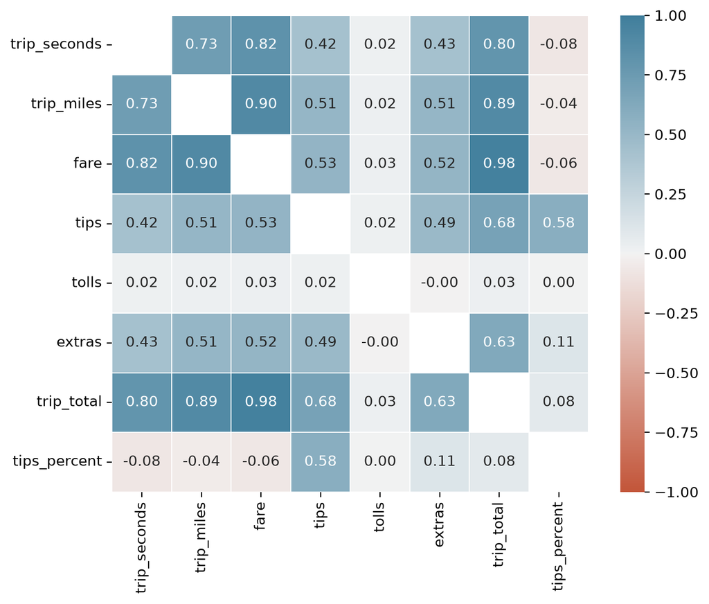

```python
# Visualize correlation matrix as heat map
fig = plt.figure(figsize=(8, 6))
sns.heatmap(C, vmin=-1, vmax=1, cmap=sns.diverging_palette(20, 230, as_cmap=True), annot=True, fmt='.2f',
            linewidths=0.1, square=True, mask=np.identity(len(numerical_cols), dtype=bool), ax=fig.gca());
```

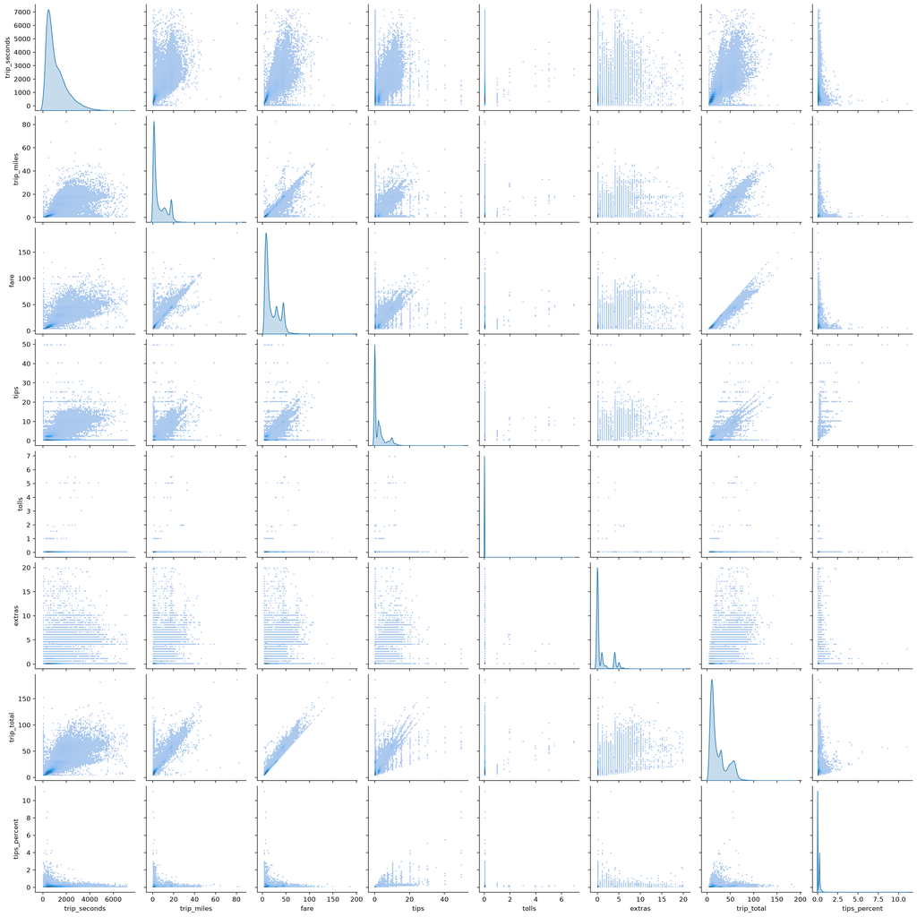

```python
# Pair plot of numerical variables
sns.pairplot(df, vars=numerical_cols, kind='hist', diag_kind='kde', plot_kws={'bins': 80});
```

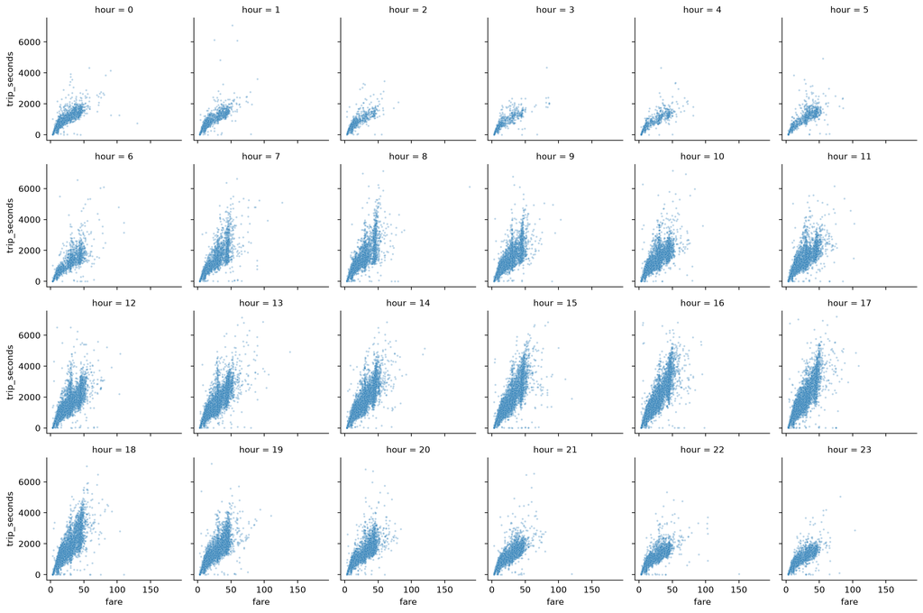

```python
sns.relplot(df, x='fare', y='trip_seconds', col='hour', col_wrap=6, height=2.5, alpha=0.3, s=5);
```

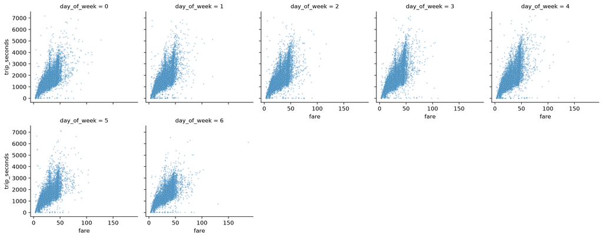

```python
sns.relplot(df, x='fare', y='trip_seconds', col='day_of_week', col_wrap=5, height=3, alpha=0.3, s=5);
```

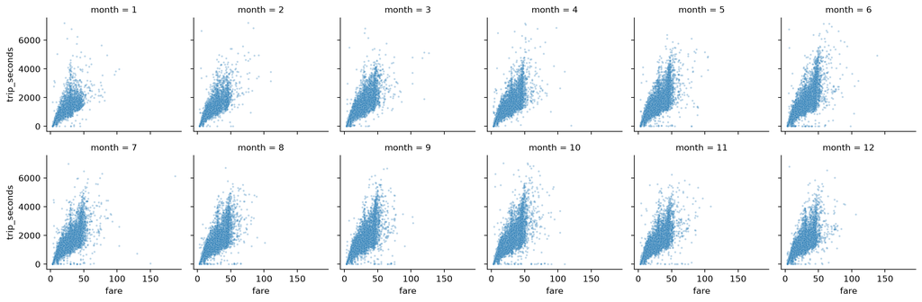

```python
sns.relplot(df, x='fare', y='trip_seconds', col='month', col_wrap=6, height=2.5, alpha=0.3, s=5);
```

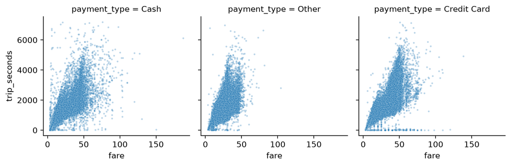

```python
sns.relplot(df, x='fare', y='trip_seconds', col='payment_type', height=3, alpha=0.3, s=5);
```

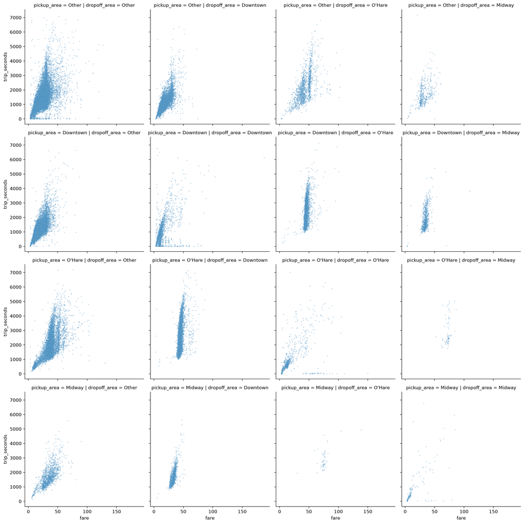

```python
sns.relplot(df, x='fare', y='trip_seconds', row='pickup_area', col='dropoff_area', height=4, alpha=0.3, s=5);
```

```python
# https://pandas.pydata.org/docs/user_guide/groupby.html
g = df.groupby(['pickup_area', 'dropoff_area'])[['trip_miles', 'trip_seconds', 'fare']]
df2 = pd.concat([g.size().rename('count'), g.mean()], axis=1) # https://pandas.pydata.org/docs/user_guide/advanced.html#advanced-hierarchical
df2['mph'] = df2['trip_miles'] / df2['trip_seconds'] * 3600
df2['$/mile'] = df2['fare'] /  df2['trip_miles']

df2.round(2)
```

| pickup_area | dropoff_area | count | trip_miles | trip_seconds | fare | mph | $/mile |
| --- | --- | --- | --- | --- | --- | --- | --- |
| Downtown | Downtown | 27193 | 1.28 | 498.11 | 7.72 | 9.22 | 6.05 |
|  | Midway | 905 | 11.89 | 1826.88 | 34.32 | 23.44 | 2.89 |
|  | O'Hare | 3399 | 16.85 | 2270.87 | 45.54 | 26.71 | 2.70 |
|  | Other | 17365 | 4.28 | 959.18 | 15.48 | 16.05 | 3.62 |
| Midway | Downtown | 1377 | 10.87 | 1706.70 | 33.18 | 22.93 | 3.05 |
|  | Midway | 143 | 4.25 | 1012.29 | 18.12 | 15.12 | 4.26 |
|  | O'Hare | 51 | 28.16 | 2900.75 | 75.46 | 34.94 | 2.68 |
|  | Other | 1451 | 11.24 | 1664.48 | 34.08 | 24.32 | 3.03 |
| O'Hare | Downtown | 7045 | 16.43 | 2438.40 | 44.89 | 24.26 | 2.73 |
|  | Midway | 72 | 26.56 | 2894.18 | 72.09 | 33.03 | 2.71 |
|  | O'Hare | 787 | 5.32 | 1038.42 | 20.51 | 18.43 | 3.86 |
|  | Other | 6821 | 13.19 | 1994.86 | 37.07 | 23.79 | 2.81 |
| Other | Downtown | 9380 | 4.13 | 967.05 | 15.40 | 15.39 | 3.73 |
|  | Midway | 439 | 10.47 | 1694.26 | 31.92 | 22.25 | 3.05 |
|  | O'Hare | 1464 | 15.23 | 2195.36 | 43.00 | 24.97 | 2.82 |
|  | Other | 22108 | 5.62 | 1184.04 | 19.73 | 17.10 | 3.51 |

# Step 5a: Simple linear regression

> **Model:** $(\text{trip seconds}) = 152.37 + 49.85\,(\text{fare})$

```python
# Method 1: smf.ols()

import statsmodels.formula.api as smf

model = smf.ols(formula='trip_seconds ~ fare', data=df).fit()
print(model.summary()) # https://www.statsmodels.org/stable/example_formulas.html
```

```
                            OLS Regression Results
==============================================================================
Dep. Variable:           trip_seconds   R-squared:                       0.679
Model:                            OLS   Adj. R-squared:                  0.679
Method:                 Least Squares   F-statistic:                 2.118e+05
Date:                Tue, 06 Oct 2026   Prob (F-statistic):               0.00
Time:                        09:47:54   Log-Likelihood:            -7.6584e+05
No. Observations:              100000   AIC:                         1.532e+06
Df Residuals:                   99998   BIC:                         1.532e+06
Df Model:                           1
Covariance Type:            nonrobust
==============================================================================
                 coef    std err          t      P>|t|      [0.025      0.975]
------------------------------------------------------------------------------
Intercept    152.3703      2.718     56.056      0.000     147.043     157.698
fare          49.8534      0.108    460.181      0.000      49.641      50.066
==============================================================================
Omnibus:                    32351.101   Durbin-Watson:                   1.663
Prob(Omnibus):                  0.000   Jarque-Bera (JB):           529232.468
Skew:                           1.122   Prob(JB):                         0.00
Kurtosis:                      14.044   Cond. No.                         42.1
==============================================================================

Notes:
[1] Standard Errors assume that the covariance matrix of the errors is correctly specified.
```

```python
model.params # See dir(model)
```

```
Intercept    152.370263
fare          49.853370
dtype: float64
```

```python
model.rsquared, model.mse_resid # See dir(model)
```

```
(np.float64(0.6792515574397406), np.float64(262739.2942218045))
```

```python
# Method 2: sm.OLS()

# import patsy # https://patsy.readthedocs.io/en/latest/formulas.html#the-formula-language
import statsmodels.api as sm

x = sm.add_constant(df['fare'])
y = df['trip_seconds']
# y, x = patsy.dmatrices('trip_seconds ~ fare', data=df, return_type='dataframe')

print(sm.OLS(y, x).fit().summary()) # https://www.statsmodels.org/stable/regression.html
```

```
                            OLS Regression Results
==============================================================================
Dep. Variable:           trip_seconds   R-squared:                       0.679
Model:                            OLS   Adj. R-squared:                  0.679
Method:                 Least Squares   F-statistic:                 2.118e+05
Date:                Tue, 06 Oct 2026   Prob (F-statistic):               0.00
Time:                        09:47:55   Log-Likelihood:            -7.6584e+05
No. Observations:              100000   AIC:                         1.532e+06
Df Residuals:                   99998   BIC:                         1.532e+06
Df Model:                           1
Covariance Type:            nonrobust
==============================================================================
                 coef    std err          t      P>|t|      [0.025      0.975]
------------------------------------------------------------------------------
const        152.3703      2.718     56.056      0.000     147.043     157.698
fare          49.8534      0.108    460.181      0.000      49.641      50.066
==============================================================================
Omnibus:                    32351.101   Durbin-Watson:                   1.663
Prob(Omnibus):                  0.000   Jarque-Bera (JB):           529232.468
Skew:                           1.122   Prob(JB):                         0.00
Kurtosis:                      14.044   Cond. No.                         42.1
==============================================================================

Notes:
[1] Standard Errors assume that the covariance matrix of the errors is correctly specified.
```

```python
# Method 3: sklearn.linear_model.LinearRegression()

import sklearn.linear_model # https://scikit-learn.org/stable/modules/generated/sklearn.linear_model.LinearRegression.html

x = df[['fare']] # (n,1)-shape
y = df['trip_seconds'] # (n,)-shape
model = sklearn.linear_model.LinearRegression(fit_intercept=True).fit(x, y)
```

```python
model.intercept_, model.coef_
```

```
(np.float64(152.37026290623896), array([49.85336985]))
```

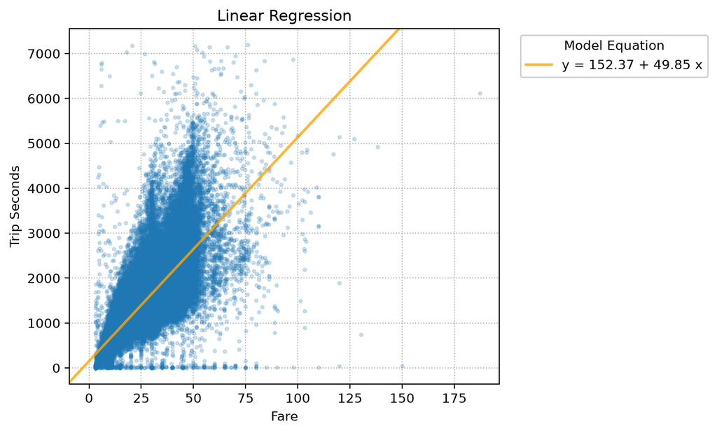

```python
plt.figure(figsize=(6, 5))

plt.plot(df['fare'], df['trip_seconds'], '.', markersize=5, alpha=0.2)
plt.axline((0, model.intercept_), slope=model.coef_[0], linewidth=2, color='orange', alpha=0.8,
           label=f'y = {model.intercept_:.2f} + {model.coef_[0]:.2f} x')
plt.grid(linestyle=':')
plt.xlabel('Fare')
plt.ylabel('Trip Seconds')
plt.title('Linear Regression')
plt.legend(framealpha=1, bbox_to_anchor=(1.5, 1), title='Model Equation')
plt.show()
```

```python
# Compute mean squared error MSE
import sklearn.metrics

y_pred = model.predict(x) # Fitted / predicted value
mse = np.mean((y - y_pred) ** 2)

(mse,
 sklearn.metrics.mean_squared_error(y, y_pred)) # https://scikit-learn.org/stable/modules/model_evaluation.html#mean-squared-error
```

```
(np.float64(262734.0394359199), 262734.0394359199)
```

```python
# Compute root mean squared error RMSE
(np.sqrt(mse),
 sklearn.metrics.root_mean_squared_error(y, y_pred))
```

```
(np.float64(512.5758865142993), 512.5758865142993)
```

```python
# Compute various sums of squares
ss_reg = np.sum((y_pred - np.mean(y)) ** 2)
ss_error = np.sum((y - y_pred) ** 2)
ss_total = np.sum((y - np.mean(y)) ** 2) # SST = SSR + SSE

ss_reg, ss_error, ss_total
```

```
(np.float64(55639398917.97122),
 np.float64(26273403943.591988),
 np.float64(81912802861.56335))
```

```python
# Compute coefficient of determination R^2
(np.corrcoef(y, y_pred)[0,1] ** 2, # Corr(y, y_pred)
 ss_reg / ss_total, # SSR / SST
 1 - ss_error / ss_total, # 1 - SSE / SST
 model.score(x, y),
 sklearn.metrics.r2_score(y, y_pred))
```

```
(np.float64(0.6792515574397499),
 np.float64(0.6792515574397391),
 np.float64(0.6792515574397409),
 0.6792515574397409,
 0.6792515574397409)
```

# Step 5b: Multiple linear regression

> **Model:** $(\text{trip seconds}) = 170.00 + 49.76\,(\text{fare}) - 118.31\,(\text{tips percent})$

```python
# Method 1: smf.ols()
print(smf.ols(formula='trip_seconds ~ fare + tips_percent', data=df).fit().summary())
```

```
                            OLS Regression Results
==============================================================================
Dep. Variable:           trip_seconds   R-squared:                       0.680
Model:                            OLS   Adj. R-squared:                  0.680
Method:                 Least Squares   F-statistic:                 1.061e+05
Date:                Tue, 06 Oct 2026   Prob (F-statistic):               0.00
Time:                        09:47:56   Log-Likelihood:            -7.6575e+05
No. Observations:              100000   AIC:                         1.532e+06
Df Residuals:                   99997   BIC:                         1.532e+06
Df Model:                           2
Covariance Type:            nonrobust
================================================================================
                   coef    std err          t      P>|t|      [0.025      0.975]
--------------------------------------------------------------------------------
Intercept      169.9954      3.034     56.037      0.000     164.050     175.941
fare            49.7615      0.108    458.749      0.000      49.549      49.974
tips_percent  -118.3052      9.072    -13.040      0.000    -136.087    -100.523
==============================================================================
Omnibus:                    32197.256   Durbin-Watson:                   1.661
Prob(Omnibus):                  0.000   Jarque-Bera (JB):           526830.241
Skew:                           1.115   Prob(JB):                         0.00
Kurtosis:                      14.021   Cond. No.                         142.
==============================================================================

Notes:
[1] Standard Errors assume that the covariance matrix of the errors is correctly specified.
```

```python
x = sm.add_constant(df[['fare', 'tips_percent']]) # Design matrix with a column of 1's for the intercept term
y = df['trip_seconds']

x.head(2)
```

|  | const | fare | tips_percent |
| --- | --- | --- | --- |
| 0 | 1.0 | 4.25 | 0.0 |
| 1 | 1.0 | 8.50 | 0.0 |

```python
# Method 2: sm.OLS()
print(sm.OLS(y, x).fit().summary())
```

```
                            OLS Regression Results
==============================================================================
Dep. Variable:           trip_seconds   R-squared:                       0.680
Model:                            OLS   Adj. R-squared:                  0.680
Method:                 Least Squares   F-statistic:                 1.061e+05
Date:                Tue, 06 Oct 2026   Prob (F-statistic):               0.00
Time:                        09:47:56   Log-Likelihood:            -7.6575e+05
No. Observations:              100000   AIC:                         1.532e+06
Df Residuals:                   99997   BIC:                         1.532e+06
Df Model:                           2
Covariance Type:            nonrobust
================================================================================
                   coef    std err          t      P>|t|      [0.025      0.975]
--------------------------------------------------------------------------------
const          169.9954      3.034     56.037      0.000     164.050     175.941
fare            49.7615      0.108    458.749      0.000      49.549      49.974
tips_percent  -118.3052      9.072    -13.040      0.000    -136.087    -100.523
==============================================================================
Omnibus:                    32197.256   Durbin-Watson:                   1.661
Prob(Omnibus):                  0.000   Jarque-Bera (JB):           526830.241
Skew:                           1.115   Prob(JB):                         0.00
Kurtosis:                      14.021   Cond. No.                         142.
==============================================================================

Notes:
[1] Standard Errors assume that the covariance matrix of the errors is correctly specified.
```

```python
# Method 3: sklearn.linear_model.LinearRegression()
x = df[['fare', 'tips_percent']]
y = df['trip_seconds']
model = sklearn.linear_model.LinearRegression(fit_intercept=True).fit(x, y)

model.intercept_, model.coef_, model.score(x, y) # R^2
```

```
(np.float64(169.995402467016),
 array([  49.76145196, -118.30515646]),
 0.6797960584655361)
```

```python
# Method 4: Closed-form mathematical formula (but numerically unstable)
one_x = np.c_[np.ones(x.shape[0]), x]

np.linalg.inv(one_x.T @ one_x) @ one_x.T @ y
```

```
array([ 169.99540247,   49.76145196, -118.30515646])
```

```python
# Method 5: np.linalg.lstsq()
beta, residuals, matrix_rank, singular_values = np.linalg.lstsq(one_x, y)

beta
```

```
array([ 169.99540247,   49.76145196, -118.30515646])
```

# Step 6a: Multicollinearity of explanatory variables

> **Model:** $(\text{trip seconds}) = 152.37 + 49.85\,(\text{fare})$

```python
print(smf.ols(formula='trip_seconds ~ fare', data=df).fit().summary())
```

```
                            OLS Regression Results
==============================================================================
Dep. Variable:           trip_seconds   R-squared:                       0.679
Model:                            OLS   Adj. R-squared:                  0.679
Method:                 Least Squares   F-statistic:                 2.118e+05
Date:                Tue, 06 Oct 2026   Prob (F-statistic):               0.00
Time:                        09:47:56   Log-Likelihood:            -7.6584e+05
No. Observations:              100000   AIC:                         1.532e+06
Df Residuals:                   99998   BIC:                         1.532e+06
Df Model:                           1
Covariance Type:            nonrobust
==============================================================================
                 coef    std err          t      P>|t|      [0.025      0.975]
------------------------------------------------------------------------------
Intercept    152.3703      2.718     56.056      0.000     147.043     157.698
fare          49.8534      0.108    460.181      0.000      49.641      50.066
==============================================================================
Omnibus:                    32351.101   Durbin-Watson:                   1.663
Prob(Omnibus):                  0.000   Jarque-Bera (JB):           529232.468
Skew:                           1.122   Prob(JB):                         0.00
Kurtosis:                      14.044   Cond. No.                         42.1
==============================================================================

Notes:
[1] Standard Errors assume that the covariance matrix of the errors is correctly specified.
```

```python
df2 = df[['trip_seconds', 'fare']].copy()
df2['fare_2'] = df2['fare'] * 2

df2.head(2)
```

|  | trip_seconds | fare | fare_2 |
| --- | --- | --- | --- |
| 0 | 151 | 4.25 | 8.5 |
| 1 | 918 | 8.50 | 17.0 |

```python
np.corrcoef(df2['fare'], df2['fare_2'])[0,1] # Corr(fare, 2 * fare) = 1
```

```
np.float64(0.9999999999999999)
```

> **Model:** $(\text{trip seconds}) = 152.37 + \beta_1\,(\text{fare}) + \beta_2\,(\text{fare} \times2)$

```python
print(smf.ols(formula='trip_seconds ~ fare + fare_2', data=df2).fit().summary()) # Parameter estimation is very sensitive and non-unique
```

```
                            OLS Regression Results
==============================================================================
Dep. Variable:           trip_seconds   R-squared:                       0.679
Model:                            OLS   Adj. R-squared:                  0.679
Method:                 Least Squares   F-statistic:                 2.118e+05
Date:                Tue, 06 Oct 2026   Prob (F-statistic):               0.00
Time:                        09:47:56   Log-Likelihood:            -7.6584e+05
No. Observations:              100000   AIC:                         1.532e+06
Df Residuals:                   99998   BIC:                         1.532e+06
Df Model:                           1
Covariance Type:            nonrobust
==============================================================================
                 coef    std err          t      P>|t|      [0.025      0.975]
------------------------------------------------------------------------------
Intercept    152.3703      2.718     56.056      0.000     147.043     157.698
fare           9.9707      0.022    460.181      0.000       9.928      10.013
fare_2        19.9413      0.043    460.181      0.000      19.856      20.026
==============================================================================
Omnibus:                    32351.101   Durbin-Watson:                   1.663
Prob(Omnibus):                  0.000   Jarque-Bera (JB):           529232.468
Skew:                           1.122   Prob(JB):                         0.00
Kurtosis:                      14.044   Cond. No.                     2.75e+16
==============================================================================

Notes:
[1] Standard Errors assume that the covariance matrix of the errors is correctly specified.
[2] The smallest eigenvalue is 4.17e-25. This might indicate that there are
strong multicollinearity problems or that the design matrix is singular.
```

```python
# Fare and trip miles are highly correlated
np.corrcoef(df['fare'], df['trip_miles'])[0,1]
```

```
np.float64(0.9031626773336535)
```

> **Model:** $(\text{trip seconds}) = 520.45 + 103.91 (\text{trip miles})$

```python
print(smf.ols(formula='trip_seconds ~ trip_miles', data=df).fit().summary())
```

```
                            OLS Regression Results
==============================================================================
Dep. Variable:           trip_seconds   R-squared:                       0.536
Model:                            OLS   Adj. R-squared:                  0.536
Method:                 Least Squares   F-statistic:                 1.153e+05
Date:                Tue, 06 Oct 2026   Prob (F-statistic):               0.00
Time:                        09:47:56   Log-Likelihood:            -7.8434e+05
No. Observations:              100000   AIC:                         1.569e+06
Df Residuals:                   99998   BIC:                         1.569e+06
Df Model:                           1
Covariance Type:            nonrobust
==============================================================================
                 coef    std err          t      P>|t|      [0.025      0.975]
------------------------------------------------------------------------------
Intercept    520.4517      2.704    192.486      0.000     515.152     525.751
trip_miles   103.9060      0.306    339.632      0.000     103.306     104.506
==============================================================================
Omnibus:                    49048.589   Durbin-Watson:                   1.764
Prob(Omnibus):                  0.000   Jarque-Bera (JB):           456999.570
Skew:                           2.163   Prob(JB):                         0.00
Kurtosis:                      12.538   Cond. No.                         12.3
==============================================================================

Notes:
[1] Standard Errors assume that the covariance matrix of the errors is correctly specified.
```

> **Model:** $(\text{trip seconds}) = 136.71 + 53.55 (\text{fare}) - 9.61 (\text{trip miles})$

```python
print(smf.ols(formula='trip_seconds ~ fare + trip_miles', data=df).fit().summary()) # Poor model explainability
```

```
                            OLS Regression Results
==============================================================================
Dep. Variable:           trip_seconds   R-squared:                       0.680
Model:                            OLS   Adj. R-squared:                  0.680
Method:                 Least Squares   F-statistic:                 1.063e+05
Date:                Tue, 06 Oct 2026   Prob (F-statistic):               0.00
Time:                        09:47:57   Log-Likelihood:            -7.6571e+05
No. Observations:              100000   AIC:                         1.531e+06
Df Residuals:                   99997   BIC:                         1.531e+06
Df Model:                           2
Covariance Type:            nonrobust
==============================================================================
                 coef    std err          t      P>|t|      [0.025      0.975]
------------------------------------------------------------------------------
Intercept    136.7063      2.881     47.458      0.000     131.060     142.352
fare          53.5529      0.252    212.494      0.000      53.059      54.047
trip_miles    -9.6139      0.592    -16.253      0.000     -10.773      -8.455
==============================================================================
Omnibus:                    30535.706   Durbin-Watson:                   1.666
Prob(Omnibus):                  0.000   Jarque-Bera (JB):           589639.179
Skew:                           0.987   Prob(JB):                         0.00
Kurtosis:                      14.731   Cond. No.                         47.3
==============================================================================

Notes:
[1] Standard Errors assume that the covariance matrix of the errors is correctly specified.
```

# Step 6b: [Variance inflation factor](https://en.wikipedia.org/wiki/Variance_inflation_factor) VIF

```python
numerical_x_cols = list(set(numerical_cols) - {'trip_seconds'}) # Omit y

r2 = {}
for col in numerical_x_cols:
    x = df[numerical_x_cols].drop(col, axis='columns')
    y = df[col]
    model = sklearn.linear_model.LinearRegression(fit_intercept=True).fit(x, y)
    r2[col] = model.score(x, y) # R^2

pd.DataFrame.from_dict(r2, orient='index').rename(columns={0: 'r2'}).eval('vif = 1 / (1 - r2)')
```

|  | r2 | vif |
| --- | --- | --- |
| trip_total | 0.999677 | 3092.085515 |
| tips_percent | 0.546423 | 2.204698 |
| extras | 0.971570 | 35.174672 |
| tips | 0.991980 | 124.692212 |
| fare | 0.999512 | 2049.046456 |
| trip_miles | 0.820697 | 5.577154 |
| tolls | 0.052419 | 1.055319 |

```python
import statsmodels.stats.outliers_influence

df2 = sm.add_constant(df[numerical_x_cols])

vif = {}
for i, col in enumerate(numerical_x_cols, 1):
    vif[col] = statsmodels.stats.outliers_influence.variance_inflation_factor(df2, i)

pd.DataFrame.from_dict(vif, orient='index').rename(columns={0: 'vif'})
```

|  | vif |
| --- | --- |
| trip_total | 3092.085515 |
| tips_percent | 2.204698 |
| extras | 35.174672 |
| tips | 124.692212 |
| fare | 2049.046456 |
| trip_miles | 5.577154 |
| tolls | 1.055319 |

# Step 7: [Polynomial regression](https://en.wikipedia.org/wiki/Polynomial_regression)

> **Model:** $(\text{trip seconds}) = -4.15 + 67.74\,(\text{fare}) - 0.32\,(\text{fare})^2$

```python
model = smf.ols(formula='trip_seconds ~ fare + I(fare ** 2)', data=df).fit()
print(model.summary())
```

```
                            OLS Regression Results
==============================================================================
Dep. Variable:           trip_seconds   R-squared:                       0.689
Model:                            OLS   Adj. R-squared:                  0.689
Method:                 Least Squares   F-statistic:                 1.109e+05
Date:                Tue, 06 Oct 2026   Prob (F-statistic):               0.00
Time:                        09:47:57   Log-Likelihood:            -7.6425e+05
No. Observations:              100000   AIC:                         1.529e+06
Df Residuals:                   99997   BIC:                         1.529e+06
Df Model:                           2
Covariance Type:            nonrobust
================================================================================
                   coef    std err          t      P>|t|      [0.025      0.975]
--------------------------------------------------------------------------------
Intercept       -4.1469      3.839     -1.080      0.280     -11.671       3.378
fare            67.7444      0.332    203.863      0.000      67.093      68.396
I(fare ** 2)    -0.3238      0.006    -56.845      0.000      -0.335      -0.313
==============================================================================
Omnibus:                    36908.594   Durbin-Watson:                   1.636
Prob(Omnibus):                  0.000   Jarque-Bera (JB):           451343.993
Skew:                           1.429   Prob(JB):                         0.00
Kurtosis:                      13.007   Cond. No.                     2.60e+03
==============================================================================

Notes:
[1] Standard Errors assume that the covariance matrix of the errors is correctly specified.
[2] The condition number is large, 2.6e+03. This might indicate that there are
strong multicollinearity or other numerical problems.
```

```python
# Create polynomial explanatory variables
import sklearn.preprocessing

def poly(x, p):
    x = np.asarray(x).reshape(-1, 1) # (n,1)-shape
    return sklearn.preprocessing.PolynomialFeatures(degree=p, include_bias=False).fit_transform(x) # (n,p)-shape

poly(np.arange(5), 3)
```

```
array([[ 0.,  0.,  0.],
       [ 1.,  1.,  1.],
       [ 2.,  4.,  8.],
       [ 3.,  9., 27.],
       [ 4., 16., 64.]])
```

```python
x = poly(df['fare'], 2) # (n,2)-shape
y = df['trip_seconds'] # (n,)-shape
model = sklearn.linear_model.LinearRegression(fit_intercept=True).fit(x, y)

model.intercept_, model.coef_, model.score(x, y) # R^2
```

```
(np.float64(-4.146885400883548),
 array([67.74437072, -0.32377666]),
 0.6892919623507452)
```

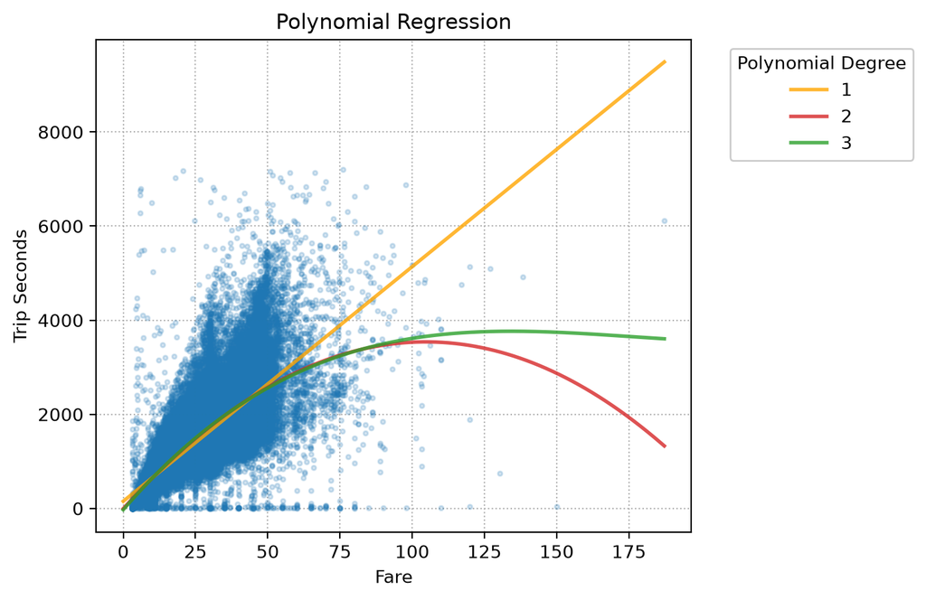

```python
plt.figure(figsize=(6, 5))

plt.plot(df['fare'], df['trip_seconds'], '.', markersize=5, alpha=0.2)

xticks = np.linspace(0, df['fare'].max(), num=1000)
for p, color in zip([1, 2, 3], ['orange', 'C3', 'C2']):
    model = sklearn.linear_model.LinearRegression(fit_intercept=True).fit(poly(df['fare'], p), df['trip_seconds'])
    plt.plot(xticks, model.predict(poly(xticks, p)), linewidth=2, color=color, alpha=0.8, label=p)

plt.grid(linestyle=':')
plt.xlabel('Fare')
plt.ylabel('Trip Seconds')
plt.title('Polynomial Regression')
plt.legend(framealpha=1, bbox_to_anchor=(1.05, 1), title='Polynomial Degree')

plt.show()
```

# Step 8a: Binary / indicator categorical explanatory variable

```python
df['night'] = ~df['hour'].between(7, 20) # Binary indicator variable
```

```python
# Q: Distribution of "night" variable?
df['night'].value_counts() / df['night'].count()
```

```
night
False    0.82816
True     0.17184
Name: count, dtype: float64
```

> **Model:** $(\text{trip seconds}) = 200.48 + 50.28(\text{fare}) -330.35\times\mathbf{1}_{\{\text{night}\}}$

```python
print(smf.ols(formula='trip_seconds ~ fare + night', data=df).fit().summary())
```

```
                            OLS Regression Results
==============================================================================
Dep. Variable:           trip_seconds   R-squared:                       0.698
Model:                            OLS   Adj. R-squared:                  0.698
Method:                 Least Squares   F-statistic:                 1.156e+05
Date:                Tue, 06 Oct 2026   Prob (F-statistic):               0.00
Time:                        09:47:58   Log-Likelihood:            -7.6280e+05
No. Observations:              100000   AIC:                         1.526e+06
Df Residuals:                   99997   BIC:                         1.526e+06
Df Model:                           2
Covariance Type:            nonrobust
=================================================================================
                    coef    std err          t      P>|t|      [0.025      0.975]
---------------------------------------------------------------------------------
Intercept       200.4770      2.706     74.086      0.000     195.173     205.781
night[T.True]  -330.3451      4.174    -79.147      0.000    -338.526    -322.165
fare             50.2833      0.105    477.827      0.000      50.077      50.490
==============================================================================
Omnibus:                    33548.778   Durbin-Watson:                   1.768
Prob(Omnibus):                  0.000   Jarque-Bera (JB):           605574.078
Skew:                           1.151   Prob(JB):                         0.00
Kurtosis:                      14.834   Cond. No.                         67.8
==============================================================================

Notes:
[1] Standard Errors assume that the covariance matrix of the errors is correctly specified.
```

```python
x = sm.add_constant(df[['fare', 'night']].astype(float)) # Convert night from True/False to 1/0 explicitly
y = df['trip_seconds']

print(sm.OLS(y, x).fit().summary())
```

```
                            OLS Regression Results
==============================================================================
Dep. Variable:           trip_seconds   R-squared:                       0.698
Model:                            OLS   Adj. R-squared:                  0.698
Method:                 Least Squares   F-statistic:                 1.156e+05
Date:                Tue, 06 Oct 2026   Prob (F-statistic):               0.00
Time:                        09:47:58   Log-Likelihood:            -7.6280e+05
No. Observations:              100000   AIC:                         1.526e+06
Df Residuals:                   99997   BIC:                         1.526e+06
Df Model:                           2
Covariance Type:            nonrobust
==============================================================================
                 coef    std err          t      P>|t|      [0.025      0.975]
------------------------------------------------------------------------------
const        200.4770      2.706     74.086      0.000     195.173     205.781
fare          50.2833      0.105    477.827      0.000      50.077      50.490
night       -330.3451      4.174    -79.147      0.000    -338.526    -322.165
==============================================================================
Omnibus:                    33548.778   Durbin-Watson:                   1.768
Prob(Omnibus):                  0.000   Jarque-Bera (JB):           605574.078
Skew:                           1.151   Prob(JB):                         0.00
Kurtosis:                      14.834   Cond. No.                         67.8
==============================================================================

Notes:
[1] Standard Errors assume that the covariance matrix of the errors is correctly specified.
```

```python
x = df[['fare', 'night']]
y = df['trip_seconds']
model = sklearn.linear_model.LinearRegression(fit_intercept=True).fit(x, y) # Convert night from True/False to 1/0 implicitly

model.intercept_, model.coef_, model.score(x, y) # R^2
```

```
(np.float64(200.47697447925498),
 array([  50.28332334, -330.34513323]),
 0.6981603461041885)
```

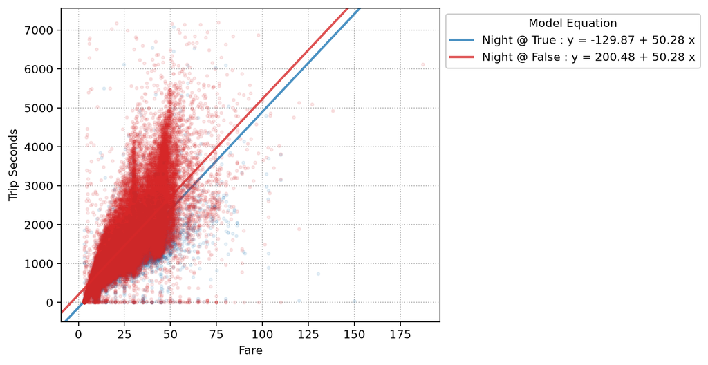

```python
plt.figure(figsize=(6, 5))

is_night = df['night']

b0 = model.intercept_ + model.coef_[1]
b1 = model.coef_[0]
plt.plot(df['fare'][is_night], df['trip_seconds'][is_night], '.', markersize=5, alpha=0.1, color='C0')
plt.axline((0, b0), slope=b1, linewidth=2, color='C0', alpha=0.8, label=f'Night @ True : y = {b0:.2f} + {b1:.2f} x')

b0 = model.intercept_
b1 = model.coef_[0]
plt.plot(df['fare'][~is_night], df['trip_seconds'][~is_night], '.', markersize=5, alpha=0.1, color='C3')
plt.axline((0, b0), slope=b1, linewidth=2, color='C3', alpha=0.8, label=f'Night @ False : y = {b0:.2f} + {b1:.2f} x')

plt.grid(linestyle=':')
plt.xlabel('Fare')
plt.ylabel('Trip Seconds')
plt.legend(framealpha=1, bbox_to_anchor=(1, 1), title='Model Equation')

plt.show()
```

# Step 8b: One-hot encoding / dummy explanatory variable

```python
hour_type = {'Rush Hour': {7, 8, 9, 15, 16, 17, 18},
             'Night': {0, 1, 2, 3, 4, 5, 6, 21, 22, 23},
             'Other': {10, 11, 12, 13, 14, 19, 20}}
df['hour_type'] = pd.Series(data='', index=df.index)
for type, hours in hour_type.items():
    df.loc[df['hour'].isin(hours), 'hour_type'] = type

df.head(2)
```

|  | trip_id | taxi_id | month | day_of_week | hour | pickup_area | dropoff_area | trip_miles | trip_seconds | fare | tips | tips_percent | tolls | extras | trip_total | payment_type | company | night | hour_type |
| --- | --- | --- | --- | --- | --- | --- | --- | --- | --- | --- | --- | --- | --- | --- | --- | --- | --- | --- | --- |
| 0 | 259f9c40ef9 | f9bc93 | 1 | 5 | 0 | Other | Other | 0.35 | 151 | 4.25 | 0.0 | 0.0 | 0.0 | 1.0 | 5.25 | Cash | City Service | True | Night |
| 1 | 0f61207c6d8 | 271cde | 1 | 5 | 0 | Downtown | Other | 0.53 | 918 | 8.50 | 0.0 | 0.0 | 0.0 | 0.0 | 8.50 | Cash | Sun Taxi | True | Night |

```python
# Q: Distribution of "hour_type" variable?
df['hour_type'].value_counts() / df['hour_type'].count()
```

```
hour_type
Other        0.42043
Rush Hour    0.40773
Night        0.17184
Name: count, dtype: float64
```

```python
# Before one-hot encoding
df[['trip_seconds', 'fare', 'hour_type']].head(2)
```

|  | trip_seconds | fare | hour_type |
| --- | --- | --- | --- |
| 0 | 151 | 4.25 | Night |
| 1 | 918 | 8.50 | Night |

> **Model:** $(\text{trip seconds}) = b_0 + b_1(\text{fare}) + b_2\times\mathbf{1}_{\{\text{hour type = Night}\}} + b_3\times\mathbf{1}_{\{\text{hour type = Other}\}} + b_4\times\mathbf{1}_{\{\text{hour type = Rush Hour}\}}$

```python
# After one-hot encoding
pd.get_dummies(df[['trip_seconds', 'fare', 'hour_type']], columns=['hour_type']).head(2)
```

|  | trip_seconds | fare | hour_type_Night | hour_type_Other | hour_type_Rush Hour |
| --- | --- | --- | --- | --- | --- |
| 0 | 151 | 4.25 | True | False | False |
| 1 | 918 | 8.50 | True | False | False |

> **Model:** $(\text{trip seconds}) = -132.38 + 50.40(\text{fare}) + 260.27\times\mathbf{1}_{\{\text{hour type = Other}\}} + 403.08\times\mathbf{1}_{\{\text{hour type = Rush Hour}\}}$

```python
# Method 1: Omit one level of the one-hot encoding
print(smf.ols(formula='trip_seconds ~ fare + hour_type', data=df).fit().summary()) # Drop first level implicitly
```

```
                            OLS Regression Results
==============================================================================
Dep. Variable:           trip_seconds   R-squared:                       0.703
Model:                            OLS   Adj. R-squared:                  0.703
Method:                 Least Squares   F-statistic:                 7.901e+04
Date:                Tue, 06 Oct 2026   Prob (F-statistic):               0.00
Time:                        09:47:59   Log-Likelihood:            -7.6194e+05
No. Observations:              100000   AIC:                         1.524e+06
Df Residuals:                   99996   BIC:                         1.524e+06
Df Model:                           3
Covariance Type:            nonrobust
==========================================================================================
                             coef    std err          t      P>|t|      [0.025      0.975]
------------------------------------------------------------------------------------------
Intercept               -132.3833      4.397    -30.105      0.000    -141.002    -123.764
hour_type[T.Other]       260.2728      4.467     58.268      0.000     251.518     269.028
hour_type[T.Rush Hour]   403.0791      4.491     89.747      0.000     394.276     411.882
fare                      50.3985      0.104    482.888      0.000      50.194      50.603
==============================================================================
Omnibus:                    32935.759   Durbin-Watson:                   1.799
Prob(Omnibus):                  0.000   Jarque-Bera (JB):           631353.589
Skew:                           1.104   Prob(JB):                         0.00
Kurtosis:                      15.110   Cond. No.                         112.
==============================================================================

Notes:
[1] Standard Errors assume that the covariance matrix of the errors is correctly specified.
```

```python
df2 = pd.get_dummies(df[['trip_seconds', 'fare', 'hour_type']], columns=['hour_type'], drop_first=True) # Drop first level

x = df2[['fare', 'hour_type_Other', 'hour_type_Rush Hour']]
y = df2['trip_seconds']
model = sklearn.linear_model.LinearRegression(fit_intercept=True).fit(x, y) # Has intercept

model.intercept_, model.coef_, model.score(x, y) # R^2
```

```
(np.float64(-132.38326962258316),
 array([ 50.39850078, 260.27280843, 403.07905532]),
 0.7033101407066041)
```

> **Model:** $(\text{trip seconds}) = 0 + 50.40 (\text{fare}) - 132.38 \times\mathbf{1}_{\{\text{hour type = Night}\}} + 127.89 \times\mathbf{1}_{\{\text{hour type = Other}\}} + 270.70 \times\mathbf{1}_{\{\text{hour type = Rush Hour}\}}$

```python
# Method 2: Keep all levels of the one-hot encoding but omit the intercept term
print(smf.ols(formula='trip_seconds ~ 0 + fare + hour_type', data=df).fit().summary())
# https://stat.ethz.ch/R-manual/R-devel/library/stats/html/formula.html
```

```
                            OLS Regression Results
==============================================================================
Dep. Variable:           trip_seconds   R-squared:                       0.703
Model:                            OLS   Adj. R-squared:                  0.703
Method:                 Least Squares   F-statistic:                 7.901e+04
Date:                Tue, 06 Oct 2026   Prob (F-statistic):               0.00
Time:                        09:47:59   Log-Likelihood:            -7.6194e+05
No. Observations:              100000   AIC:                         1.524e+06
Df Residuals:                   99996   BIC:                         1.524e+06
Df Model:                           3
Covariance Type:            nonrobust
========================================================================================
                           coef    std err          t      P>|t|      [0.025      0.975]
----------------------------------------------------------------------------------------
hour_type[Night]      -132.3833      4.397    -30.105      0.000    -141.002    -123.764
hour_type[Other]       127.8895      3.199     39.979      0.000     121.620     134.159
hour_type[Rush Hour]   270.6958      3.168     85.438      0.000     264.486     276.906
fare                    50.3985      0.104    482.888      0.000      50.194      50.603
==============================================================================
Omnibus:                    32935.759   Durbin-Watson:                   1.799
Prob(Omnibus):                  0.000   Jarque-Bera (JB):           631353.589
Skew:                           1.104   Prob(JB):                         0.00
Kurtosis:                      15.110   Cond. No.                         78.8
==============================================================================

Notes:
[1] Standard Errors assume that the covariance matrix of the errors is correctly specified.
```

```python
df2 = pd.get_dummies(df[['trip_seconds', 'fare', 'hour_type']], columns=['hour_type']) # Don't drop any level

x = df2[['fare', 'hour_type_Night', 'hour_type_Other', 'hour_type_Rush Hour']]
y = df2['trip_seconds']
model = sklearn.linear_model.LinearRegression(fit_intercept=False).fit(x, y) # No intercept

model.intercept_, model.coef_, model.score(x, y) # R^2
```

```
(0.0,
 array([  50.39850078, -132.38326962,  127.88953881,  270.6957857 ]),
 0.7033101407066041)
```

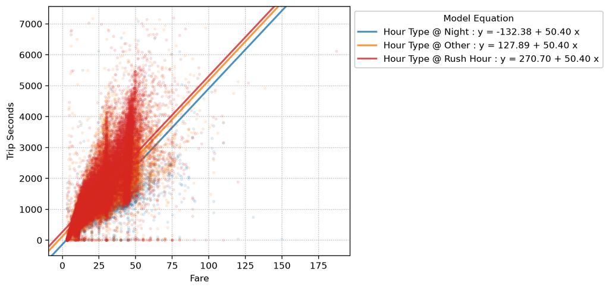

```python
plt.figure(figsize=(6, 5))

for i, (type, color) in enumerate(zip(['Night', 'Other', 'Rush Hour'], ['C0', 'C1', 'C3']), 1):
    is_type = df['hour_type'] == type
    b0 = model.coef_[i]
    b1 = model.coef_[0]
    plt.plot(df['fare'][is_type], df['trip_seconds'][is_type], '.', markersize=5, alpha=0.1, color=color)
    plt.axline((0, b0), slope=b1, linewidth=2, color=color, alpha=0.8, label=f'Hour Type @ {type} : y = {b0:.2f} + {b1:.2f} x')

plt.grid(linestyle=':')
plt.xlabel('Fare')
plt.ylabel('Trip Seconds')
plt.legend(framealpha=1, bbox_to_anchor=(1, 1), title='Model Equation')

plt.show()
```

# Step 8c: Interaction term

> **Model:** $$\begin{align*}(\text{trip seconds}) &=128.67 + 53.91(\text{fare}) + 119.65 \times\mathbf{1}_{\{\text{night}\}} - 20.95 (\text{fare})\mathbf{1}_{\{\text{night}\}}\\&= (128.67 + 119.65 \times\mathbf{1}_{\{\text{night}\}}) + (53.91 - 20.95 \times\mathbf{1}_{\{\text{night}\}})(\text{fare})\end{align*}$$

```python
print(smf.ols(formula='trip_seconds ~ fare + night + fare:night', data=df).fit().summary()) # Same as 'trip_seconds ~ fare * night'
```

```
                            OLS Regression Results
==============================================================================
Dep. Variable:           trip_seconds   R-squared:                       0.715
Model:                            OLS   Adj. R-squared:                  0.715
Method:                 Least Squares   F-statistic:                 8.374e+04
Date:                Tue, 06 Oct 2026   Prob (F-statistic):               0.00
Time:                        09:48:00   Log-Likelihood:            -7.5988e+05
No. Observations:              100000   AIC:                         1.520e+06
Df Residuals:                   99996   BIC:                         1.520e+06
Df Model:                           3
Covariance Type:            nonrobust
======================================================================================
                         coef    std err          t      P>|t|      [0.025      0.975]
--------------------------------------------------------------------------------------
Intercept            128.6740      2.786     46.179      0.000     123.213     134.135
night[T.True]        119.6524      7.078     16.906      0.000     105.780     133.524
fare                  53.9117      0.112    479.634      0.000      53.691      54.132
fare:night[T.True]   -20.9475      0.270    -77.562      0.000     -21.477     -20.418
==============================================================================
Omnibus:                    33890.441   Durbin-Watson:                   1.770
Prob(Omnibus):                  0.000   Jarque-Bera (JB):           705380.787
Skew:                           1.126   Prob(JB):                         0.00
Kurtosis:                      15.815   Cond. No.                         121.
==============================================================================

Notes:
[1] Standard Errors assume that the covariance matrix of the errors is correctly specified.
```

```python
x = df[['fare', 'night']].copy()
x['fare:night'] = x['fare'] * x['night'] # Interaction term

y = df['trip_seconds']
model = sklearn.linear_model.LinearRegression(fit_intercept=True).fit(x, y) # Convert night from True/False to 1/0 implicitly

model.intercept_, model.coef_, model.score(x, y) # R^2
```

```
(np.float64(128.6739596642301),
 array([ 53.91167894, 119.65237512, -20.94746187]),
 0.7152887966372689)
```

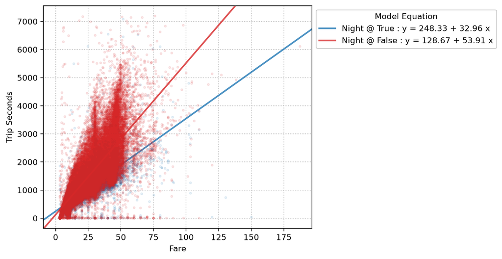

```python
plt.figure(figsize=(6, 5))

is_night = df['night']

b0 = model.intercept_ + model.coef_[1]
b1 = model.coef_[0] + model.coef_[2]
plt.plot(df['fare'][is_night], df['trip_seconds'][is_night], '.', markersize=5, alpha=0.1, color='C0')
plt.axline((0, b0), slope=b1, linewidth=2, color='C0', alpha=0.8,
           label=f'Night @ True : y = {b0:.2f} + {b1:.2f} x')

b0 = model.intercept_
b1 = model.coef_[0]
plt.plot(df['fare'][~is_night], df['trip_seconds'][~is_night], '.', markersize=5, alpha=0.1, color='C3')
plt.axline((0, b0), slope=b1, linewidth=2, color='C3', alpha=0.8, label=f'Night @ False : y = {b0:.2f} + {b1:.2f} x')

plt.grid(linestyle=':')
plt.xlabel('Fare')
plt.ylabel('Trip Seconds')
plt.legend(framealpha=1, bbox_to_anchor=(1, 1), title='Model Equation')

plt.show()
```

> **Model:** $$\begin{align*}(\text{trip seconds}) =&\; 248.33 + 32.97 (\text{fare}) - 81.86 \times \mathbf{1}_{\{\text{hour type = Other}\}} - 162.76 \times\mathbf{1}_{\{\text{hour type = Rush Hour}\}}\\ &+ 15.52 (\text{fare})\mathbf{1}_{\{\text{hour type = Other}\}} + 27.00 (\text{fare})\mathbf{1}_{\{\text{hour type = Rush Hour}\}}\\ = &\;(248.33 - 81.86 \times \mathbf{1}_{\{\text{hour type = Other}\}} - 162.76 \times\mathbf{1}_{\{\text{hour type = Rush Hour}\}} )\\ &+ (32.97 + 15.52\times \mathbf{1}_{\{\text{hour type = Other}\}} + 27.00 \times \mathbf{1}_{\{\text{hour type = Rush Hour}\}}) (\text{fare})\end{align*}$$

```python
# Method 1: Omit one level of the one-hot encoding
print(smf.ols(formula='trip_seconds ~ fare + hour_type + fare:hour_type', data=df).fit().summary()) # Same as 'trip_seconds ~ fare * hour_type'
```

```
                            OLS Regression Results
==============================================================================
Dep. Variable:           trip_seconds   R-squared:                       0.728
Model:                            OLS   Adj. R-squared:                  0.728
Method:                 Least Squares   F-statistic:                 5.355e+04
Date:                Tue, 06 Oct 2026   Prob (F-statistic):               0.00
Time:                        09:48:01   Log-Likelihood:            -7.5758e+05
No. Observations:              100000   AIC:                         1.515e+06
Df Residuals:                   99994   BIC:                         1.515e+06
Df Model:                           5
Covariance Type:            nonrobust
===============================================================================================
                                  coef    std err          t      P>|t|      [0.025      0.975]
-----------------------------------------------------------------------------------------------
Intercept                     248.3263      6.358     39.055      0.000     235.864     260.789
hour_type[T.Other]            -81.8633      7.437    -11.008      0.000     -96.440     -67.287
hour_type[T.Rush Hour]       -162.7561      7.431    -21.903      0.000    -177.320    -148.192
fare                           32.9642      0.240    137.353      0.000      32.494      33.435
fare:hour_type[T.Other]        15.5264      0.285     54.541      0.000      14.968      16.084
fare:hour_type[T.Rush Hour]    27.0026      0.287     94.005      0.000      26.440      27.566
==============================================================================
Omnibus:                    32477.789   Durbin-Watson:                   1.793
Prob(Omnibus):                  0.000   Jarque-Bera (JB):           903956.245
Skew:                           0.974   Prob(JB):                         0.00
Kurtosis:                      17.600   Cond. No.                         224.
==============================================================================

Notes:
[1] Standard Errors assume that the covariance matrix of the errors is correctly specified.
```

```python
df2 = pd.get_dummies(df[['trip_seconds', 'fare', 'hour_type']], columns=['hour_type'], drop_first=True)
for col in ['hour_type_Other', 'hour_type_Rush Hour']:
    df2[f'fare:{col}'] = df2['fare'] * df2[col]

x = df2[['fare', 'hour_type_Other', 'hour_type_Rush Hour', 'fare:hour_type_Other', 'fare:hour_type_Rush Hour']]
y = df2['trip_seconds']
model = sklearn.linear_model.LinearRegression(fit_intercept=True).fit(x, y)

model.intercept_, model.coef_, model.score(x, y) # R^2
```

```
(np.float64(248.326334781789),
 array([  32.96421707,  -81.8632733 , -162.75614208,   15.52637726,
          27.00260763]),
 0.728076753807139)
```

> **Model:** $$\begin{align*}(\text{trip seconds}) =&\; 248.33 \times \mathbf{1}_{\{\text{hour type = Night}\}} + 166.46 \times \mathbf{1}_{\{\text{hour type = Other}\}} + 85.57 \times \mathbf{1}_{\{\text{hour type = Rush Hour}\}} \\ &+ 32.96 (\text{fare})\mathbf{1}_{\{\text{hour type = Night}\}} + 48.49 (\text{fare})\mathbf{1}_{\{\text{hour type = Other}\}} + 59.97 (\text{fare})\mathbf{1}_{\{\text{hour type = Rush Hour}\}}\\ =&\; (248.33 + 32.96(\text{fare}))\times \mathbf{1}_{\{\text{hour type = Night}\}} \\ &+(166.46 + 48.49(\text{fare}))\times \mathbf{1}_{\{\text{hour type = Other}\}}\\ &+(85.57 + 59.97(\text{fare}))\times \mathbf{1}_{\{\text{hour type = Rush HOur}\}}\end{align*}$$

```python
# Method 2: Keep all levels of the one-hot encoding but omit the intercept and fare terms
print(smf.ols(formula='trip_seconds ~ 0 + hour_type + fare:hour_type', data=df).fit().summary())
```

```
                            OLS Regression Results
==============================================================================
Dep. Variable:           trip_seconds   R-squared:                       0.728
Model:                            OLS   Adj. R-squared:                  0.728
Method:                 Least Squares   F-statistic:                 5.355e+04
Date:                Tue, 06 Oct 2026   Prob (F-statistic):               0.00
Time:                        09:48:01   Log-Likelihood:            -7.5758e+05
No. Observations:              100000   AIC:                         1.515e+06
Df Residuals:                   99994   BIC:                         1.515e+06
Df Model:                           5
Covariance Type:            nonrobust
=============================================================================================
                                coef    std err          t      P>|t|      [0.025      0.975]
---------------------------------------------------------------------------------------------
hour_type[Night]            248.3263      6.358     39.055      0.000     235.864     260.789
hour_type[Other]            166.4631      3.857     43.154      0.000     158.903     174.024
hour_type[Rush Hour]         85.5702      3.846     22.251      0.000      78.033      93.108
fare:hour_type[Night]        32.9642      0.240    137.353      0.000      32.494      33.435
fare:hour_type[Other]        48.4906      0.153    316.716      0.000      48.191      48.791
fare:hour_type[Rush Hour]    59.9668      0.158    379.930      0.000      59.657      60.276
==============================================================================
Omnibus:                    32477.789   Durbin-Watson:                   1.793
Prob(Omnibus):                  0.000   Jarque-Bera (JB):           903956.245
Skew:                           0.974   Prob(JB):                         0.00
Kurtosis:                      17.600   Cond. No.                         69.7
==============================================================================

Notes:
[1] Standard Errors assume that the covariance matrix of the errors is correctly specified.
```

```python
df2 = pd.get_dummies(df[['trip_seconds', 'fare', 'hour_type']], columns=['hour_type'])
for col in ['hour_type_Night', 'hour_type_Other', 'hour_type_Rush Hour']:
    df2[f'fare:{col}'] = df2['fare'] * df2[col]

x = df2[['hour_type_Night', 'hour_type_Other', 'hour_type_Rush Hour',
         'fare:hour_type_Night', 'fare:hour_type_Other', 'fare:hour_type_Rush Hour']]
y = df2['trip_seconds']
model = sklearn.linear_model.LinearRegression(fit_intercept=False).fit(x, y)

model.intercept_, model.coef_, model.score(x, y) # R^2
```

```
(0.0,
 array([248.32633478, 166.46306149,  85.5701927 ,  32.96421707,
         48.49059434,  59.9668247 ]),
 0.7280767538071391)
```

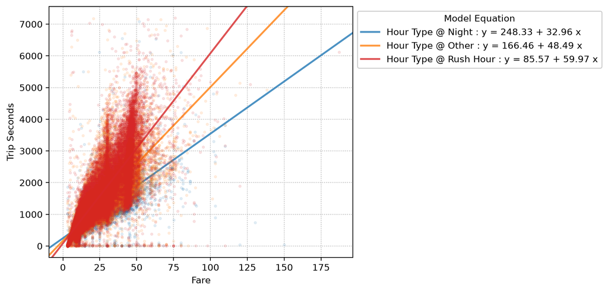

```python
plt.figure(figsize=(6, 5))

for i, (type, color) in enumerate(zip(['Night', 'Other', 'Rush Hour'], ['C0', 'C1', 'C3'])):
    is_type = df['hour_type'] == type
    b0 = model.coef_[i]
    b1 = model.coef_[3 + i]
    plt.plot(df['fare'][is_type], df['trip_seconds'][is_type], '.', markersize=5, alpha=0.1, color=color)
    plt.axline((0, b0), slope=b1, linewidth=2, color=color, alpha=0.8, label=f'Hour Type @ {type} : y = {b0:.2f} + {b1:.2f} x')

plt.grid(linestyle=':')
plt.xlabel('Fare')
plt.ylabel('Trip Seconds')
plt.legend(framealpha=1, bbox_to_anchor=(1, 1), title='Model Equation')

plt.show()
```

# Step 9: Model selection with F-test

```python
large_model = smf.ols(formula='trip_seconds ~ fare + extras', data=df).fit()
small_model = smf.ols(formula='trip_seconds ~ fare', data=df).fit()

print(large_model.summary())
```

```
                            OLS Regression Results
==============================================================================
Dep. Variable:           trip_seconds   R-squared:                       0.679
Model:                            OLS   Adj. R-squared:                  0.679
Method:                 Least Squares   F-statistic:                 1.059e+05
Date:                Tue, 06 Oct 2026   Prob (F-statistic):               0.00
Time:                        09:48:02   Log-Likelihood:            -7.6584e+05
No. Observations:              100000   AIC:                         1.532e+06
Df Residuals:                   99997   BIC:                         1.532e+06
Df Model:                           2
Covariance Type:            nonrobust
==============================================================================
                 coef    std err          t      P>|t|      [0.025      0.975]
------------------------------------------------------------------------------
Intercept    151.8238      2.731     55.593      0.000     146.471     157.177
fare          49.9900      0.127    393.737      0.000      49.741      50.239
extras        -2.0662      1.001     -2.064      0.039      -4.029      -0.104
==============================================================================
Omnibus:                    32276.160   Durbin-Watson:                   1.663
Prob(Omnibus):                  0.000   Jarque-Bera (JB):           531852.738
Skew:                           1.117   Prob(JB):                         0.00
Kurtosis:                      14.075   Cond. No.                         42.4
==============================================================================

Notes:
[1] Standard Errors assume that the covariance matrix of the errors is correctly specified.
```

```python
# Method 1: Use anova_lm()
import statsmodels.stats.api as sms

print(sms.anova_lm(small_model, large_model))
```

```
   df_resid           ssr  df_diff       ss_diff         F    Pr(>F)
0   99998.0  2.627340e+10      0.0           NaN       NaN       NaN
1   99997.0  2.627228e+10      1.0  1.119090e+06  4.259458  0.039035
```

```python
# Method 2: Use compare_f_test()
large_model.compare_f_test(small_model) # F-statistic, p-value, p_large - p_small
```

```
(np.float64(4.259457558708216),
 np.float64(0.039034957163546456),
 np.float64(1.0))
```

```python
# Method 3: Use f_test()
large_model.f_test('extras = 0')
# https://www.statsmodels.org/devel/generated/statsmodels.regression.linear_model.OLSResults.f_test.html
```

```
<class 'statsmodels.stats.contrast.ContrastResults'>
<F test: F=4.259457558663214, p=0.03903495716458052, df_denom=1e+05, df_num=1>
```

```python
# Do sequential F-tests
m1 = smf.ols(formula='trip_seconds ~ fare', data=df).fit()
m2 = smf.ols(formula='trip_seconds ~ fare + hour', data=df).fit()
m3 = smf.ols(formula='trip_seconds ~ fare + hour + fare:hour', data=df).fit()
m4 = smf.ols(formula='trip_seconds ~ fare + hour + fare:hour + tips_percent', data=df).fit()
m5 = smf.ols(formula='trip_seconds ~ fare + hour + fare:hour + tips_percent + tolls', data=df).fit()
```

```python
(m2.compare_f_test(m1),
 m3.compare_f_test(m2),
 m4.compare_f_test(m3),
 m5.compare_f_test(m4))
```

```
((np.float64(1163.3869188435378),
  np.float64(1.5966566608849715e-253),
  np.float64(1.0)),
 (np.float64(993.0169421528295),
  np.float64(6.88515242158917e-217),
  np.float64(1.0)),
 (np.float64(207.90902516560692),
  np.float64(4.3791261653445525e-47),
  np.float64(1.0)),
 (np.float64(0.3340352819104331),
  np.float64(0.5632938750202238),
  np.float64(1.0)))
```

```python
sms.anova_lm(m5)
```

|  | df | sum_sq | mean_sq | F | PR(>F) |
| --- | --- | --- | --- | --- | --- |
| fare | 1.0 | 5.563940e+10 | 5.563940e+10 | 216799.637476 | 0.000000e+00 |
| hour | 1.0 | 3.021552e+08 | 3.021552e+08 | 1177.351549 | 1.597346e-256 |
| fare:hour | 1.0 | 2.553732e+08 | 2.553732e+08 | 995.065039 | 2.495351e-217 |
| tips_percent | 1.0 | 5.335736e+07 | 5.335736e+07 | 207.907640 | 4.382172e-47 |
| tolls | 1.0 | 8.572672e+04 | 8.572672e+04 | 0.334035 | 5.632939e-01 |
| Residual | 99994.0 | 2.566243e+10 | 2.566397e+05 | NaN | NaN |

```python
# Do F-test to combine categorical levels via multiple constraints
df['hour'] = df['hour'].astype(str)
model = smf.ols(formula='trip_seconds ~ fare + hour', data=df).fit()

print(model.summary())
```

```
                            OLS Regression Results
==============================================================================
Dep. Variable:           trip_seconds   R-squared:                       0.715
Model:                            OLS   Adj. R-squared:                  0.715
Method:                 Least Squares   F-statistic:                 1.044e+04
Date:                Tue, 06 Oct 2026   Prob (F-statistic):               0.00
Time:                        09:48:03   Log-Likelihood:            -7.5997e+05
No. Observations:              100000   AIC:                         1.520e+06
Df Residuals:                   99975   BIC:                         1.520e+06
Df Model:                          24
Covariance Type:            nonrobust
==============================================================================
                 coef    std err          t      P>|t|      [0.025      0.975]
------------------------------------------------------------------------------
Intercept   -156.8786     11.671    -13.442      0.000    -179.754    -134.004
hour[T.1]      3.4602     17.883      0.193      0.847     -31.590      38.510
hour[T.10]   204.3940     13.140     15.555      0.000     178.640     230.148
hour[T.11]   228.6046     13.084     17.473      0.000     202.961     254.248
hour[T.12]   285.7705     12.961     22.048      0.000     260.366     311.175
hour[T.13]   331.3552     12.907     25.673      0.000     306.058     356.652
hour[T.14]   402.8387     12.881     31.274      0.000     377.592     428.085
hour[T.15]   488.7351     12.874     37.962      0.000     463.502     513.969
hour[T.16]   531.2102     12.832     41.397      0.000     506.060     556.361
hour[T.17]   541.8916     12.797     42.344      0.000     516.809     566.974
hour[T.18]   443.3015     12.847     34.508      0.000     418.123     468.481
hour[T.19]   288.0445     13.057     22.060      0.000     262.453     313.636
hour[T.2]     17.2387     21.058      0.819      0.413     -24.034      58.512
hour[T.20]   183.2709     13.416     13.660      0.000     156.975     209.567
hour[T.21]    96.2366     13.820      6.963      0.000      69.149     123.324
hour[T.22]    89.7318     14.254      6.295      0.000      61.794     117.669
hour[T.23]    38.7880     15.037      2.579      0.010       9.315      68.261
hour[T.3]    -79.0981     23.552     -3.358      0.001    -125.260     -32.937
hour[T.4]   -209.8695     23.089     -9.090      0.000    -255.124    -164.615
hour[T.5]   -229.0827     19.747    -11.601      0.000    -267.787    -190.378
hour[T.6]    -27.9782     16.301     -1.716      0.086     -59.928       3.971
hour[T.7]    213.4379     14.408     14.814      0.000     185.199     241.676
hour[T.8]    292.5919     13.502     21.671      0.000     266.129     319.055
hour[T.9]    246.9985     13.295     18.578      0.000     220.941     273.056
fare          50.5625      0.103    491.890      0.000      50.361      50.764
==============================================================================
Omnibus:                    33817.931   Durbin-Watson:                   1.869
Prob(Omnibus):                  0.000   Jarque-Bera (JB):           709122.052
Skew:                           1.120   Prob(JB):                         0.00
Kurtosis:                      15.852   Cond. No.                         938.
==============================================================================

Notes:
[1] Standard Errors assume that the covariance matrix of the errors is correctly specified.
```

```python
model.f_test('(hour[T.4] = hour[T.5]), (hour[T.16] = hour[T.17])')
```

```
<class 'statsmodels.stats.contrast.ContrastResults'>
<F test: F=1.147835438031094, p=0.3173270734183613, df_denom=1e+05, df_num=2>
```

# Step 10: Model diagnostic for heteroscedasticity

> **Model:** $(\text{trip seconds}) = 152.37 + 49.85\,(\text{fare})$

```python
m1 = smf.ols(formula='trip_seconds ~ fare', data=df).fit()

print(m1.summary())
```

```
                            OLS Regression Results
==============================================================================
Dep. Variable:           trip_seconds   R-squared:                       0.679
Model:                            OLS   Adj. R-squared:                  0.679
Method:                 Least Squares   F-statistic:                 2.118e+05
Date:                Tue, 06 Oct 2026   Prob (F-statistic):               0.00
Time:                        09:48:03   Log-Likelihood:            -7.6584e+05
No. Observations:              100000   AIC:                         1.532e+06
Df Residuals:                   99998   BIC:                         1.532e+06
Df Model:                           1
Covariance Type:            nonrobust
==============================================================================
                 coef    std err          t      P>|t|      [0.025      0.975]
------------------------------------------------------------------------------
Intercept    152.3703      2.718     56.056      0.000     147.043     157.698
fare          49.8534      0.108    460.181      0.000      49.641      50.066
==============================================================================
Omnibus:                    32351.101   Durbin-Watson:                   1.663
Prob(Omnibus):                  0.000   Jarque-Bera (JB):           529232.468
Skew:                           1.122   Prob(JB):                         0.00
Kurtosis:                      14.044   Cond. No.                         42.1
==============================================================================

Notes:
[1] Standard Errors assume that the covariance matrix of the errors is correctly specified.
```

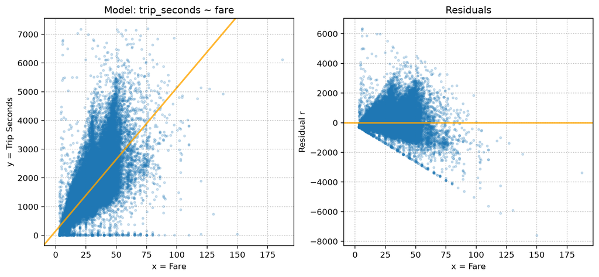

```python
plt.figure(figsize=(12, 5))

plt.subplot(1, 2, 1)
plt.plot(df['fare'], df['trip_seconds'], '.', markersize=5, alpha=0.2)
plt.axline((0, m1.params.iat[0]), slope=m1.params.iat[1], linewidth=2, color='orange', alpha=0.8)
plt.grid(linestyle=':')
plt.xlabel('x = Fare')
plt.ylabel('y = Trip Seconds')
plt.title('Model: trip_seconds ~ fare')

plt.subplot(1, 2, 2)
plt.plot(df['fare'], m1.resid, '.', markersize=5, alpha=0.2)
plt.axline((0, 0), slope=0, linewidth=2, color='orange', alpha=0.8)
plt.grid(linestyle=':')
plt.xlabel('x = Fare')
plt.ylabel('Residual r')
plt.title('Residuals')
plt.show()
```

```python
m2 = smf.ols(formula='np.log(trip_seconds) ~ np.log(fare)', data=df).fit()

print(m2.summary())
```

```
                             OLS Regression Results
================================================================================
Dep. Variable:     np.log(trip_seconds)   R-squared:                       0.700
Model:                              OLS   Adj. R-squared:                  0.700
Method:                   Least Squares   F-statistic:                 2.330e+05
Date:                  Tue, 06 Oct 2026   Prob (F-statistic):               0.00
Time:                          09:48:05   Log-Likelihood:                -70476.
No. Observations:                100000   AIC:                         1.410e+05
Df Residuals:                     99998   BIC:                         1.410e+05
Df Model:                             1
Covariance Type:              nonrobust
================================================================================
                   coef    std err          t      P>|t|      [0.025      0.975]
--------------------------------------------------------------------------------
Intercept        4.0552      0.006    704.214      0.000       4.044       4.066
np.log(fare)     0.9833      0.002    482.674      0.000       0.979       0.987
==============================================================================
Omnibus:                    94827.364   Durbin-Watson:                   1.828
Prob(Omnibus):                  0.000   Jarque-Bera (JB):          7617196.533
Skew:                          -4.411   Prob(JB):                         0.00
Kurtosis:                      44.836   Cond. No.                         11.7
==============================================================================

Notes:
[1] Standard Errors assume that the covariance matrix of the errors is correctly specified.
```

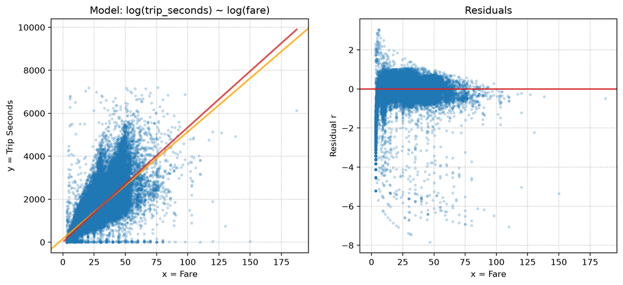

```python
plt.figure(figsize=(12, 5))

plt.subplot(1, 2, 1)
plt.plot(df['fare'], df['trip_seconds'], '.', markersize=5, alpha=0.2)
plt.axline((0, m1.params.iat[0]), slope=m1.params.iat[1], linewidth=2, color='orange', alpha=0.8)
plt.grid(linestyle=':')
plt.xlabel('x = Fare')
plt.ylabel('y = Trip Seconds')
plt.title('Model: log(trip_seconds) ~ log(fare)')

xticks = np.linspace(1, df['fare'].max(), num=1000)
plt.plot(xticks, np.exp(m2.params.iat[0] + m2.params.iat[1] * np.log(xticks)), linewidth=2, color='C3', alpha=0.8)

plt.subplot(1, 2, 2)
plt.plot(df['fare'], m2.resid, '.', markersize=5, alpha=0.2)
plt.axline((0, 0), slope=0, linewidth=2, color='C3', alpha=0.8)
plt.grid(linestyle=':')
plt.xlabel('x = Fare')
plt.ylabel('Residual r')
plt.title('Residuals')
plt.show()
```